# HR Attrition Exploratory Data Analyiss

Loading the dataset

```r
library(ggplot)
```

```
Error in library(ggplot) : there is no package called ‘ggplot’
```

So about 35 columns, 1470 rows. The dependent variable will likely be “attrition” with everything else being the x - predictors. Let’s explore the data a bit at first with a few questions:

- What are the summary statistics for attrition? On average, how long does it take for someone to leave the company? What’s the distribution of this dependent variable look like?
- How do we define attrition? What metric are we using to measure this?
- From my own intuition, which predictor variables do I think will have the highest prediction power, so I can test?
- Which variables are correlated with each other?
- What are some qualitative predictor variables? What’s does the distribution for these qualitative look like? Could there be subjective error there?

```r
summary(hr$Attrition)
```

```
  No  Yes
1233  237
```

```r
head(hr, 10)
```

|  | Age | Attrition | BusinessTravel | DailyRate | Department | DistanceFromHome | Education | EducationField | EmployeeCount | EmployeeNumber | EnvironmentSatisfaction | Gender | HourlyRate | JobInvolvement | JobLevel | JobRole | JobSatisfaction | MaritalStatus | MonthlyIncome | MonthlyRate | NumCompaniesWorked | Over18 | OverTime | PercentSalaryHike | PerformanceRating | RelationshipSatisfaction | StandardHours | StockOptionLevel | TotalWorkingYears | … |
| --- | --- | --- | --- | --- | --- | --- | --- | --- | --- | --- | --- | --- | --- | --- | --- | --- | --- | --- | --- | --- | --- | --- | --- | --- | --- | --- | --- | --- | --- | --- |
| 1 | 41 | Yes | Travel_Rarely | 1102 | Sales | 1 | 2 | Life Sciences | 1 | 1 | 2 | Female | 94 | 3 | 2 | Sales Executive | 4 | Single | 5993 | 19479 | 8 | Y | Yes | 11 | 3 | 1 | 80 | 0 | 8 | … |
| 2 | 49 | No | Travel_Frequently | 279 | Research & Development | 8 | 1 | Life Sciences | 1 | 2 | 3 | Male | 61 | 2 | 2 | Research Scientist | 2 | Married | 5130 | 24907 | 1 | Y | No | 23 | 4 | 4 | 80 | 1 | 10 | … |
| 3 | 37 | Yes | Travel_Rarely | 1373 | Research & Development | 2 | 2 | Other | 1 | 4 | 4 | Male | 92 | 2 | 1 | Laboratory Technician | 3 | Single | 2090 | 2396 | 6 | Y | Yes | 15 | 3 | 2 | 80 | 0 | 7 | … |
| 4 | 33 | No | Travel_Frequently | 1392 | Research & Development | 3 | 4 | Life Sciences | 1 | 5 | 4 | Female | 56 | 3 | 1 | Research Scientist | 3 | Married | 2909 | 23159 | 1 | Y | Yes | 11 | 3 | 3 | 80 | 0 | 8 | … |
| 5 | 27 | No | Travel_Rarely | 591 | Research & Development | 2 | 1 | Medical | 1 | 7 | 1 | Male | 40 | 3 | 1 | Laboratory Technician | 2 | Married | 3468 | 16632 | 9 | Y | No | 12 | 3 | 4 | 80 | 1 | 6 | … |
| 6 | 32 | No | Travel_Frequently | 1005 | Research & Development | 2 | 2 | Life Sciences | 1 | 8 | 4 | Male | 79 | 3 | 1 | Laboratory Technician | 4 | Single | 3068 | 11864 | 0 | Y | No | 13 | 3 | 3 | 80 | 0 | 8 | … |
| 7 | 59 | No | Travel_Rarely | 1324 | Research & Development | 3 | 3 | Medical | 1 | 10 | 3 | Female | 81 | 4 | 1 | Laboratory Technician | 1 | Married | 2670 | 9964 | 4 | Y | Yes | 20 | 4 | 1 | 80 | 3 | 12 | … |
| 8 | 30 | No | Travel_Rarely | 1358 | Research & Development | 24 | 1 | Life Sciences | 1 | 11 | 4 | Male | 67 | 3 | 1 | Laboratory Technician | 3 | Divorced | 2693 | 13335 | 1 | Y | No | 22 | 4 | 2 | 80 | 1 | 1 | … |
| 9 | 38 | No | Travel_Frequently | 216 | Research & Development | 23 | 3 | Life Sciences | 1 | 12 | 4 | Male | 44 | 2 | 3 | Manufacturing Director | 3 | Single | 9526 | 8787 | 0 | Y | No | 21 | 4 | 2 | 80 | 0 | 10 | … |
| 10 | 36 | No | Travel_Rarely | 1299 | Research & Development | 27 | 3 | Medical | 1 | 13 | 3 | Male | 94 | 3 | 2 | Healthcare Representative | 3 | Married | 5237 | 16577 | 6 | Y | No | 13 | 3 | 2 | 80 | 2 | 17 | … |

Note: - To build the model, I’m gonna need to replace these categorical variables with dummy variables. - The class is fairly imbalanced so I’ll need to keep this in mind when I go into the modeling stage.

Let’s look at multi-collinearity to see how related these quantitative variables are, so we have a solid first guess on which variables to test:

```r
install.packages("pheatmap")
install.packages("RColorBrewer")
install.packages("viridis")
```

```r
library(pheatmap)
library(RColorBrewer)
library(viridis)
names(hr)
```

```
 [1] "Age"                      "Attrition"
 [3] "BusinessTravel"           "DailyRate"
 [5] "Department"               "DistanceFromHome"
 [7] "Education"                "EducationField"
 [9] "EmployeeCount"            "EmployeeNumber"
[11] "EnvironmentSatisfaction"  "Gender"
[13] "HourlyRate"               "JobInvolvement"
[15] "JobLevel"                 "JobRole"
[17] "JobSatisfaction"          "MaritalStatus"
[19] "MonthlyIncome"            "MonthlyRate"
[21] "NumCompaniesWorked"       "Over18"
[23] "OverTime"                 "PercentSalaryHike"
[25] "PerformanceRating"        "RelationshipSatisfaction"
[27] "StandardHours"            "StockOptionLevel"
[29] "TotalWorkingYears"        "TrainingTimesLastYear"
[31] "WorkLifeBalance"          "YearsAtCompany"
[33] "YearsInCurrentRole"       "YearsSinceLastPromotion"
[35] "YearsWithCurrManager"
```

```r
str(hr)
```

```
'data.frame':   1470 obs. of  35 variables:
 $ Age                     : int  41 49 37 33 27 32 59 30 38 36 ...
 $ Attrition               : Factor w/ 2 levels "No","Yes": 2 1 2 1 1 1 1 1 1 1 ...
 $ BusinessTravel          : Factor w/ 3 levels "Non-Travel","Travel_Frequently",..: 3 2 3 2 3 2 3 3 2 3 ...
 $ DailyRate               : int  1102 279 1373 1392 591 1005 1324 1358 216 1299 ...
 $ Department              : Factor w/ 3 levels "Human Resources",..: 3 2 2 2 2 2 2 2 2 2 ...
 $ DistanceFromHome        : int  1 8 2 3 2 2 3 24 23 27 ...
 $ Education               : int  2 1 2 4 1 2 3 1 3 3 ...
 $ EducationField          : Factor w/ 6 levels "Human Resources",..: 2 2 5 2 4 2 4 2 2 4 ...
 $ EmployeeCount           : int  1 1 1 1 1 1 1 1 1 1 ...
 $ EmployeeNumber          : int  1 2 4 5 7 8 10 11 12 13 ...
 $ EnvironmentSatisfaction : int  2 3 4 4 1 4 3 4 4 3 ...
 $ Gender                  : Factor w/ 2 levels "Female","Male": 1 2 2 1 2 2 1 2 2 2 ...
 $ HourlyRate              : int  94 61 92 56 40 79 81 67 44 94 ...
 $ JobInvolvement          : int  3 2 2 3 3 3 4 3 2 3 ...
```

[output cut: 21 more lines]

```r
group_col = c('Age','DailyRate','DistanceFromHome','Education','EmployeeCount','EmployeeNumber','EnvironmentSatisfaction','JobInvolvement','JobLevel','JobSatisfaction','MonthlyIncome','MonthlyRate','NumCompaniesWorked','PercentSalaryHike','PerformanceRating','RelationshipSatisfaction','StandardHours','StockOptionLevel','TotalWorkingYears','TrainingTimesLastYear','WorkLifeBalance','YearsAtCompany','YearsInCurrentRole','YearsSinceLastPromotion','YearsWithCurrManager')
quant_var = hr[group_col]
pheatmap(
  mat               = quant_var,
  color             = inferno(10),
  border_color      = NA,
  show_colnames     = FALSE,
  show_rownames     = FALSE,
  #annotation_col    = mat_col,
  #annotation_colors = mat_colors,
  drop_levels       = TRUE,
  fontsize          = 14,
  main              = "Default Heatmap"
)
```

[output not shown]

```r
install.packages('ggplot2')
```

```
Error in install.packages : Updating loaded packages
```

```r
library('ggplot2')
library('reshape2')
cor_matrix = cor(quant_var)
```

```
the standard deviation is zero
```

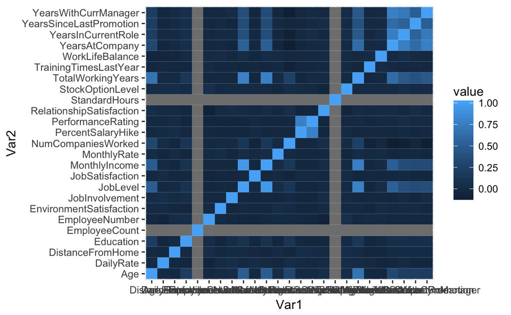

```r
melted_cormat = melt(cor_matrix)
ggplot(data = melted_cormat,aes(x=Var1, y=Var2, fill=value)) +
  geom_tile()
```

```r
names(hr)
```

```
 [1] "Age"                      "Attrition"
 [3] "BusinessTravel"           "DailyRate"
 [5] "Department"               "DistanceFromHome"
 [7] "Education"                "EducationField"
 [9] "EmployeeCount"            "EmployeeNumber"
[11] "EnvironmentSatisfaction"  "Gender"
[13] "HourlyRate"               "JobInvolvement"
[15] "JobLevel"                 "JobRole"
[17] "JobSatisfaction"          "MaritalStatus"
[19] "MonthlyIncome"            "MonthlyRate"
[21] "NumCompaniesWorked"       "Over18"
[23] "OverTime"                 "PercentSalaryHike"
[25] "PerformanceRating"        "RelationshipSatisfaction"
[27] "StandardHours"            "StockOptionLevel"
[29] "TotalWorkingYears"        "TrainingTimesLastYear"
[31] "WorkLifeBalance"          "YearsAtCompany"
[33] "YearsInCurrentRole"       "YearsSinceLastPromotion"
[35] "YearsWithCurrManager"
```

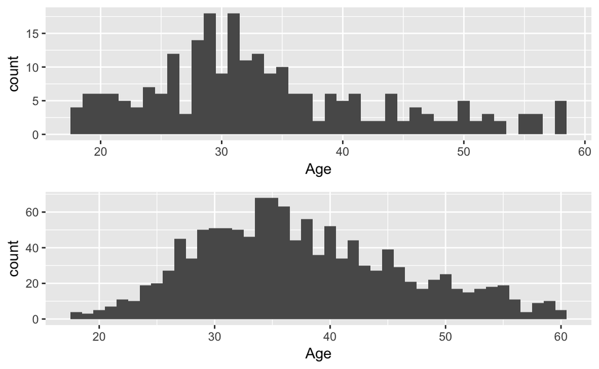

```r
summary(turned_over$Age)
```

```
   Min. 1st Qu.  Median    Mean 3rd Qu.    Max.
  18.00   28.00   32.00   33.61   39.00   58.00
```

```r
summary(incumbent$Age)
```

```
   Min. 1st Qu.  Median    Mean 3rd Qu.    Max.
  18.00   31.00   36.00   37.56   43.00   60.00
```

So it looks like on average, employees who stay tend to be older while employees who are younger tend to leave.

```r
by(hr$JobLevel, hr$Attrition, summary)
```

```
hr$Attrition: No
   Min. 1st Qu.  Median    Mean 3rd Qu.    Max.
  1.000   1.000   2.000   2.146   3.000   5.000
-----------------------------------------------------------
hr$Attrition: Yes
   Min. 1st Qu.  Median    Mean 3rd Qu.    Max.
  1.000   1.000   1.000   1.637   2.000   5.000
```

Notes: It looks like most employees are at a lower joblevel, which makes sense, however, it looks like those who are at a lower job level are more likely to leave, my guess, is that it’s because they’re not getting promoted.

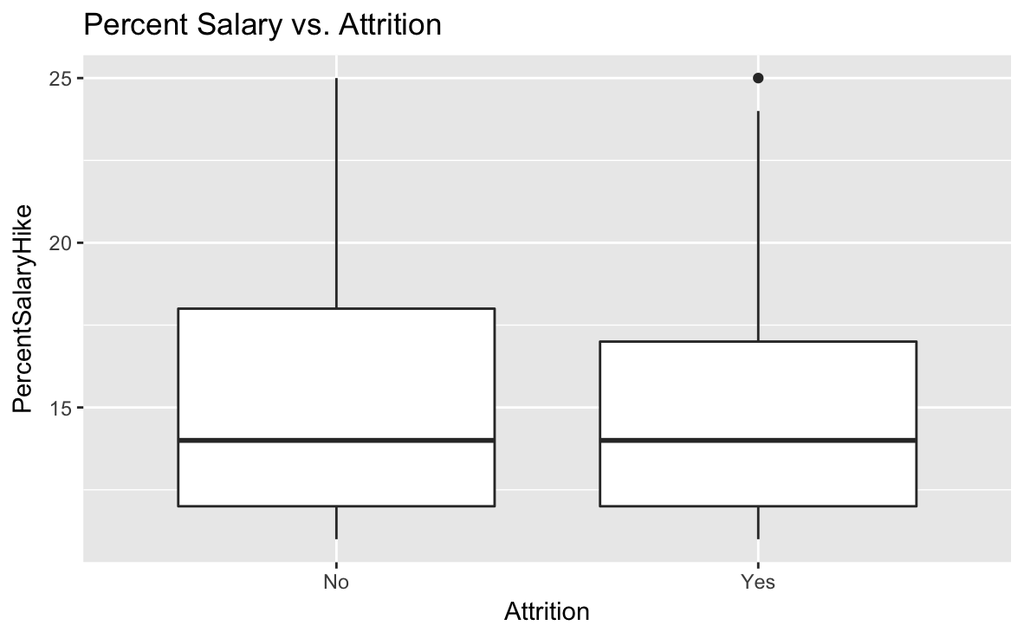

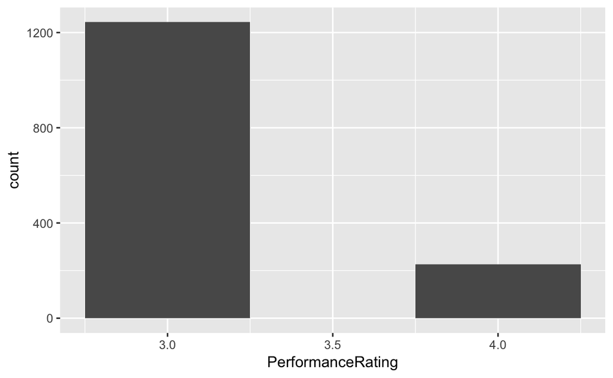

We can see that a majority of people get a rating of 3, while only a select few get a rating of 4. Let’s look at the Performance Rating distribution from turned over employees versus non-turnover.

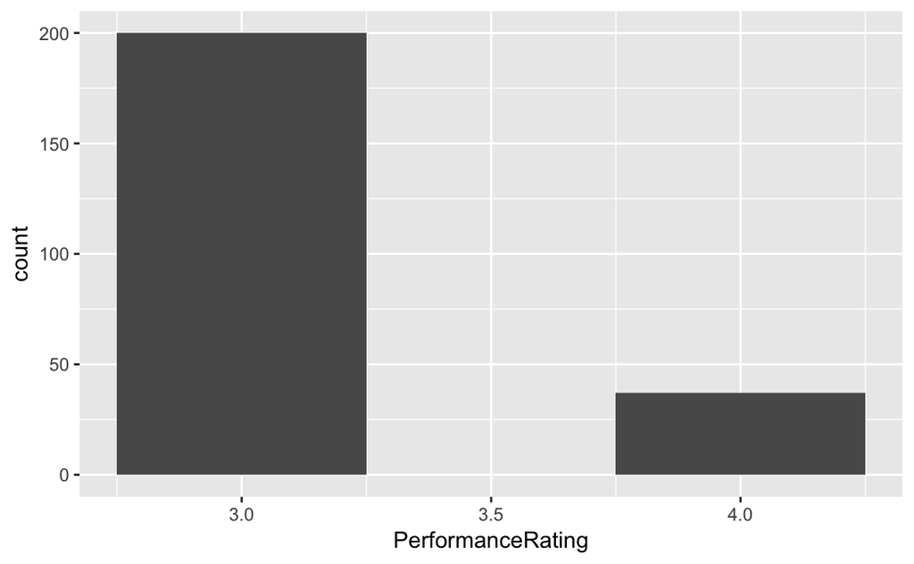

```r
hr$Gender
```

[output not shown]

[output cut: 87 more lines]

You can see that there doesn’t seem to be a big difference.

```r
by(hr$Attrition,hr$Gender, summary)
```

```
hr$Gender: Female
 No Yes
501  87
-----------------------------------------------------------
hr$Gender: Male
 No Yes
732 150
```

Interesting. Looks men have about 3% higher turnover than women. Could there be a gender behavioral difference?

```r
87/501
```

```
[1] 0.1736527
```

```r
150/732
```

```
[1] 0.204918
```

```r
hr$Attrition
```

[output not shown]